# DV_FProject

Brian Yeh, Valentina Chen

# Dataset: Employee Salaries in Montgomery county, Maryland

### Summary of Dataset

```
##              FULL_NAME    GENDER     DEPARTMENT
##  Carter, Jerome   :   2   F:3713   POL    :1840
##  Cruz, Angela     :   2   M:5387   HHS    :1550
##  Aarhus, Pam J    :   1            FRS    :1309
##  Aaron, David J   :   1            DOT    :1186
##  Aaron, Marsha M  :   1            COR    : 499
##  Ababio, Godfred A:   1            DGS    : 430
##  (Other)          :9092            (Other):2286
##                                 DEPARTMENT_NAME
##  Department of Police                   :1840
##  Department of Health and Human Services:1550
##  Fire and Rescue Services               :1309
##  Department of Transportation           :1186
##  Correction and Rehabilitation          : 499
##  Department of General Services         : 430
##  (Other)                                :2286
##                                        DIVISION
##  School Health Services                    : 297
##  Transit Silver Spring Ride On             : 277
##  Transit Gaithersburg Ride On              : 273
##  Highway Services                          : 217
##  Child Welfare Services                    : 199
##  FSB Traffic Division School Safety Section: 166
##  (Other)                                   :7671
##        ASSIGNMENT_CATEGORY                             POSITION_TITLE
##  Fulltime-Regular:8244     Police Officer III                 : 886
##  Parttime-Regular: 856     Firefighter/Rescuer III            : 697
##                            Bus Operator                       : 606
##                            Manager III                        : 245
##                            Correctional Officer III (Corporal): 234
##                            Office Services Coordinator        : 218
##                            (Other)                            :6214
##                      UNDERFILLED_JOB_TITLE   DATE_FIRST_HIRED
##  null                           :7982      2013-01-14:  90
##  Firefighter/Rescuer II         : 255      2014-02-24:  77
##  Police Officer I               : 188      2014-03-10:  72
##  Firefighter/Rescuer I (Recruit): 111      2014-09-22:  70
##  Correctional Officer II (PFC)  :  64      2014-10-06:  66
##  Police Officer II              :  54      2013-08-12:  63
##  (Other)                        : 446      (Other)   :8662
##  CURRENT_ANNUAL_SALARY X2014_GROSS_PAY_RECEIVED
##  Min.   :  7200        Min.   :     0
##  1st Qu.: 49418        1st Qu.: 51383
##  Median : 65561        Median : 71217
##  Mean   : 69843        Mean   : 73362
##  3rd Qu.: 87425        3rd Qu.: 94023
##  Max.   :294263        Max.   :298023
##
##            X2014_OVERTIME_PAY       YR           RANGE
##  null               :2893     Min.   :1955   Min.   : 13000
##  26.4099998474121   :  16     1st Qu.:1996   1st Qu.: 51000
##  0.00999999977648258:  14     Median :2003   Median : 71000
##  67.0500030517578   :   9     Mean   :2002   Mean   : 73032
##  58.4300003051758   :   7     3rd Qu.:2009   3rd Qu.: 90000
##  13.8100004196167   :   6     Max.   :2014   Max.   :289000
##  (Other)            :6155
```

### Histogram Current Annual Salary

Made Histogram of Current Annual Salary with average salary line

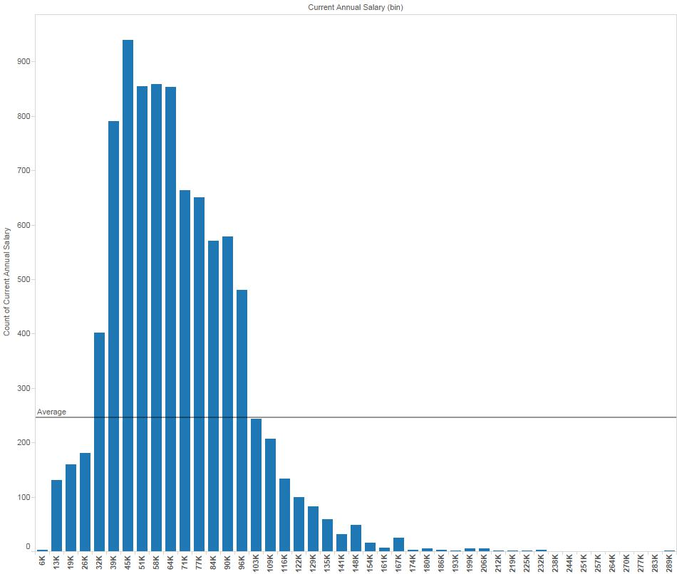

SQL Query: select range,count(full_name) as count from salary group by range

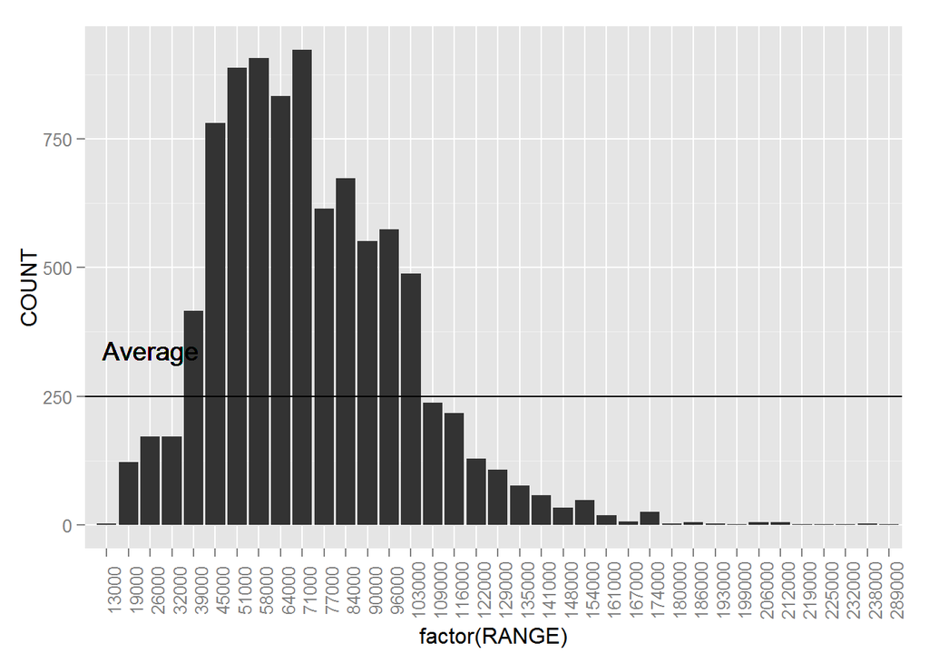

```r
 setwd("C:/Users/Brian Yeh/Github/DataVisualization/DV_FProject")
 source("./01Data/Dataframes_All.R", echo = FALSE)

   df3 %>% ggplot(., aes(x = factor(RANGE), y = COUNT)) + geom_bar(position = "identity", stat = "identity")+
        theme(axis.text.x = element_text(angle = 90)) + geom_hline(aes(yintercept=250)) +
    geom_text(aes(0,245,label = "Average", vjust = -2, hjust = -.18))
```

[Shiny URL](https://by2578.shinyapps.io/ShinyFinal)

### Histogram2

Histogram of Current annual Salary with overtime pay on dual axis, average lines for both

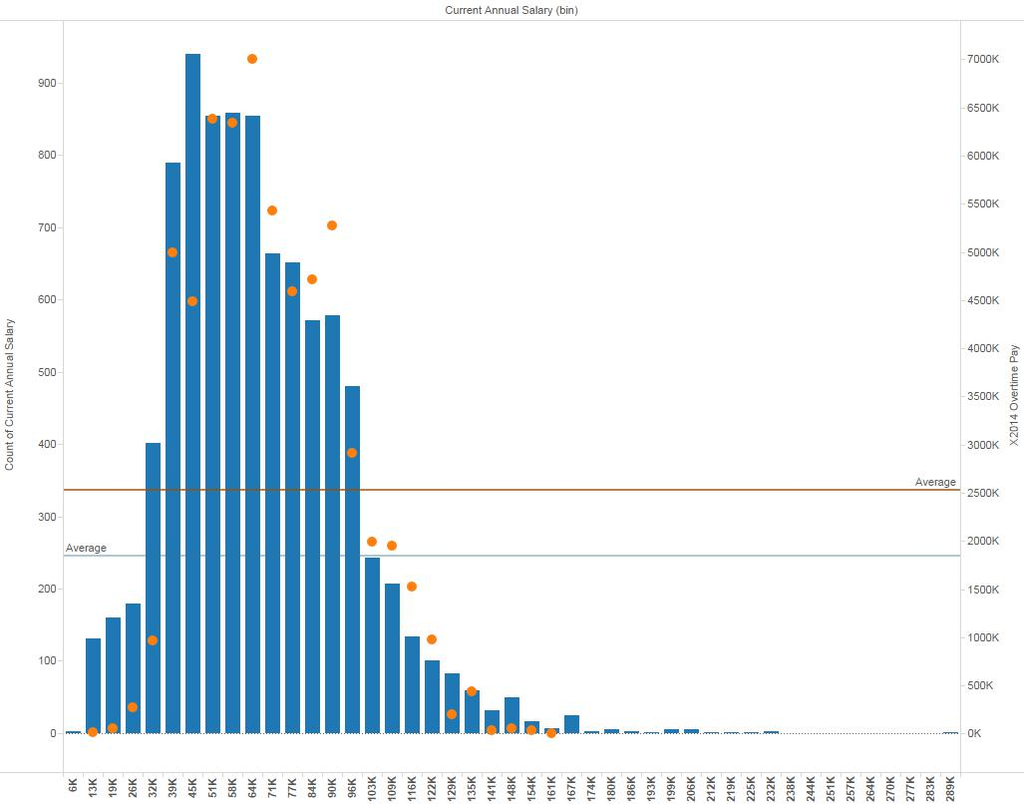

## Packed Bubble

Which departments are paid the most as shown by size of bubble and color

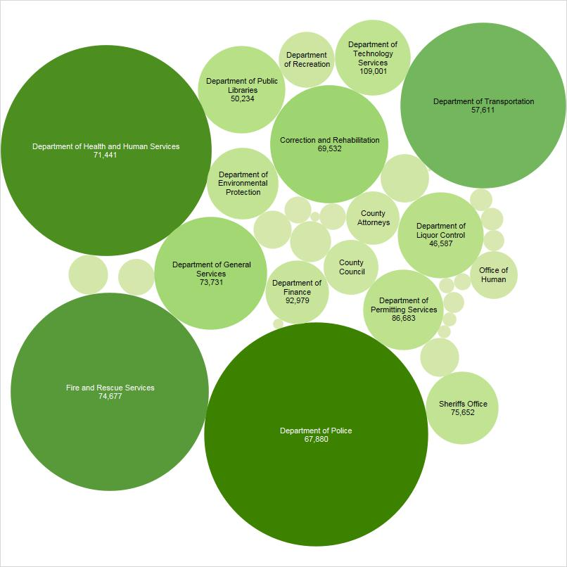

## TreeMap

What positions get paid the most as shown by treemap. Includes average salary.

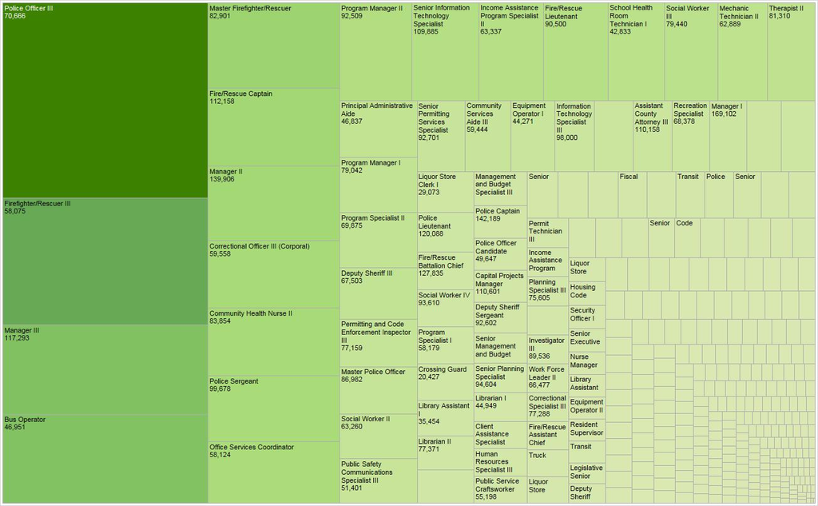

# CrossTab/KPI

In the Office of Management and Budget, which division/position get the highes percent of their salary from overtime?

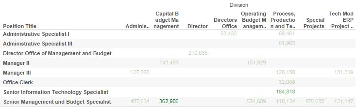

KPI = overtime/current salary  
Filter by Department = Office of Management and Budget

# Four Highest Paid Positions

Which four positions is the highest paid by average salary?

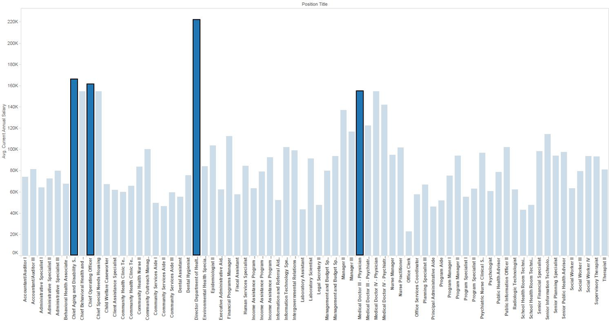

Chief Aging and Disability Services  
Chief Operating Officer  
Director Department of Health and Human Services  
Medical Doctor III - Physician

Filter by Department of Health and Human Services

# Four Highest Set In

Used Set in filters to show Salary of four highest paid positions

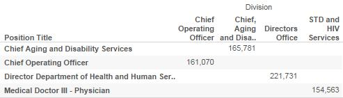

# Overtime Ratio (High/Low)

Which divisions/positions have high or low Overtime ratios? Filter by sheriffs office

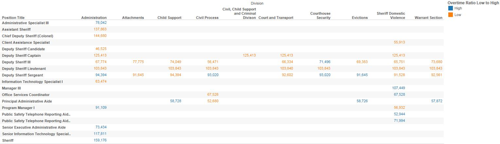

[Shiny URL](https://by2578.shinyapps.io/ShinyFinal)

# Barchart

Who makes over 150,000 and doesn’t work that much overtime?

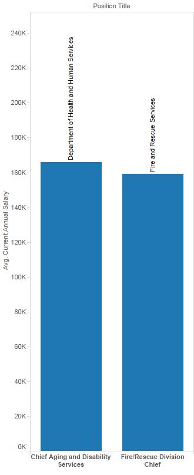

# Non-Aggregate Measures

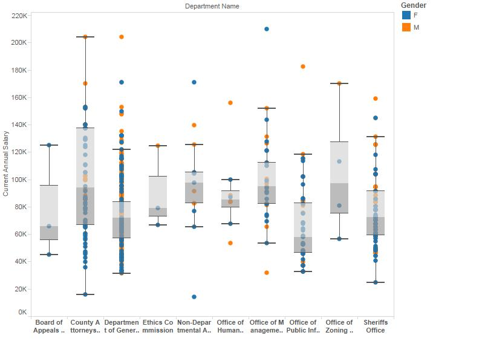

# ScatterPlot

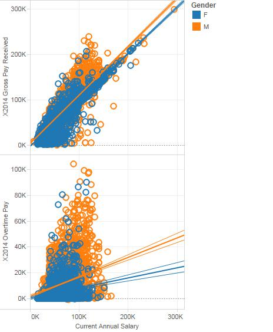

# Barchart

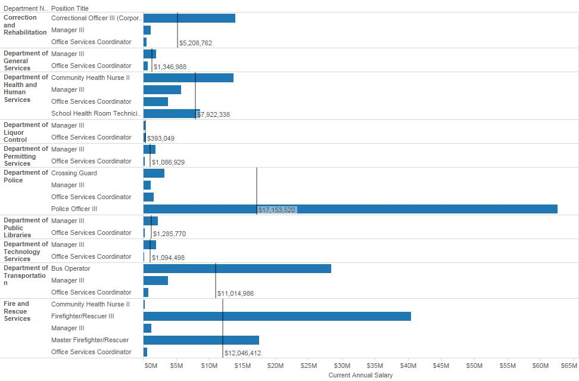

# Line - Gender

## R code for Line graph

Query: select GENDER, yr, round(sum(Current_annual_salary),0) as sum from salary group by GENDER, yr;

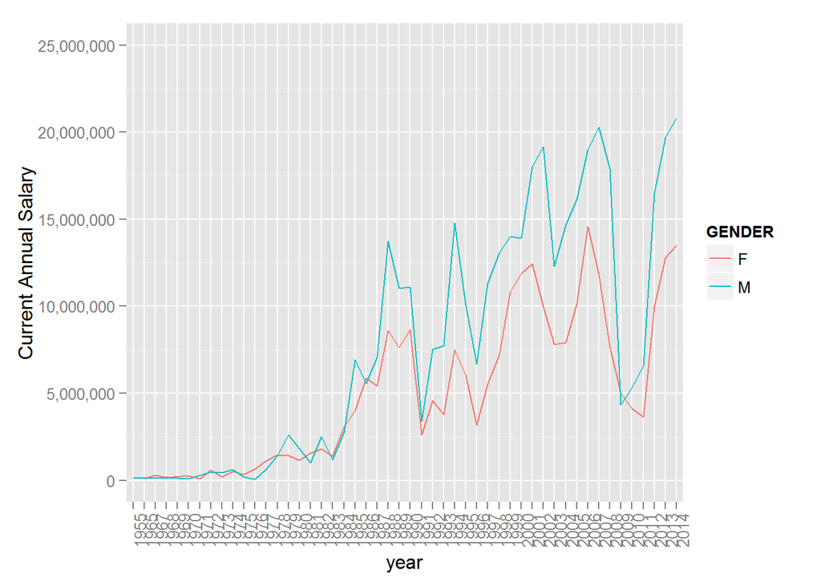

```r
setwd("C:/Users/Brian Yeh/Github/DataVisualization/DV_FProject")
source("./01Data/Dataframes_All.R", echo = FALSE)

df1$year <- substr(df1$DATE_FIRST_HIRED, 0,4)

df1 %>% group_by(GENDER, year) %>% summarise(sum=sum(CURRENT_ANNUAL_SALARY)) %>% ggplot(data=., aes(x=year, y=sum, group=GENDER, colour=GENDER)) +
        geom_line() + ylab("Current Annual Salary") +
      theme(axis.text.x = element_text(angle = 90, hjust = 1)) +
      scale_y_continuous(limits=c(0, 25000000), labels= comma)
```

[Shiny URL](https://by2578.shinyapps.io/ShinyFinal)

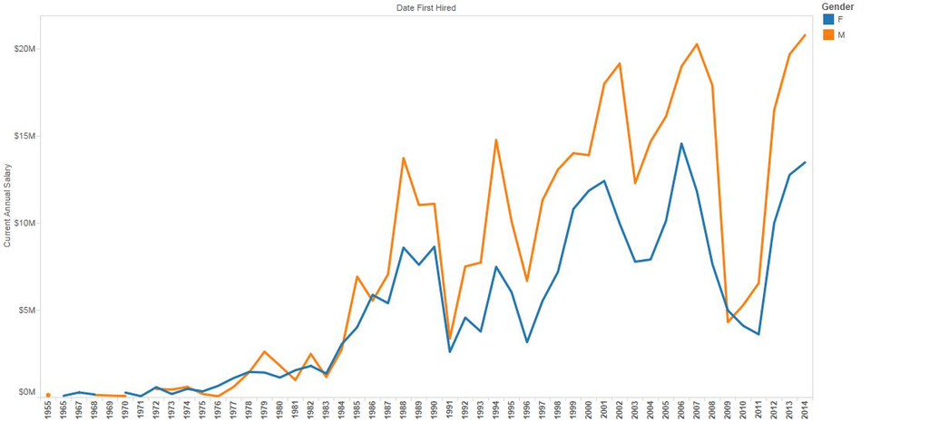

# Calculated Difference

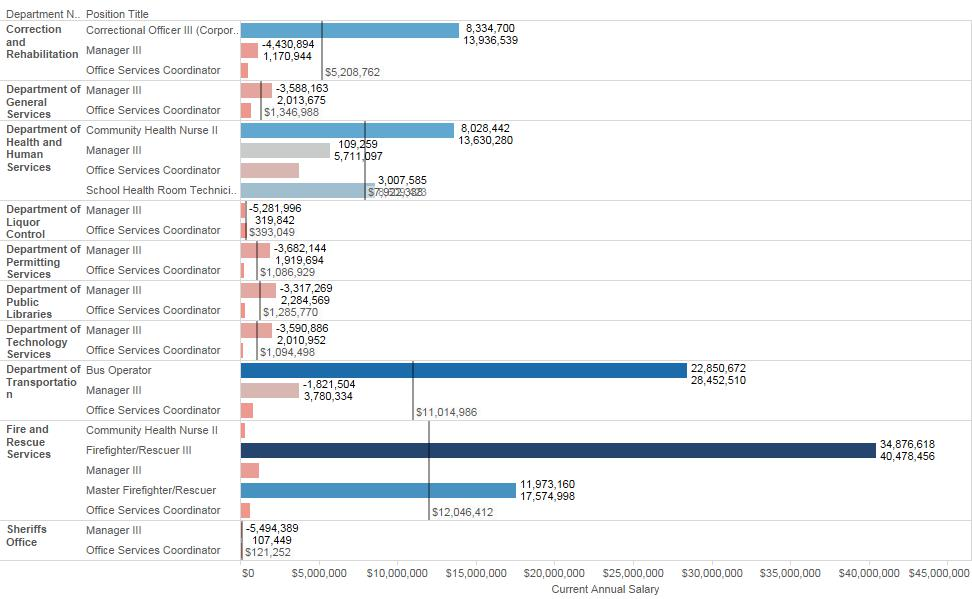